# Lab 03 - Exploratory Data Analysis

Joey Hotz

January 27, 2022

# Learning Goals

- Read in and get familiar with the meteorology dataset
- Step through the EDA “checklist” presented in the class slides
- Practice making exploratory graphs

# Lab Description

We will work with the meteorological data presented in lecture. Recall the dataset consists of weather station readings in the continental US.

**The objective of the lab is to find the weather station with the highest elevation and look at patterns in the time series of its wind speed and temperature.**

# Steps

### 1. Read in the data

First download and then read in with data.table:fread()

```r
download.file(
  "https://raw.githubusercontent.com/JSC370/jsc370-2022/main/labs/lab03/met_all.gz",
  destfile = "met_all.gz",
  method   = "curl",
  timeout  = 60
  )

met <- data.table::fread("met_all.gz")
```

### 2. Check the dimensions, headers, footers. How many columns, rows are there?

```r
dim(met)
```

```
## [1] 2377343      30
```

```r
head(met)
```

```
##    USAFID  WBAN year month day hour min  lat      lon elev wind.dir wind.dir.qc
## 1: 690150 93121 2019     8   1    0  56 34.3 -116.166  696      220           5
## 2: 690150 93121 2019     8   1    1  56 34.3 -116.166  696      230           5
## 3: 690150 93121 2019     8   1    2  56 34.3 -116.166  696      230           5
## 4: 690150 93121 2019     8   1    3  56 34.3 -116.166  696      210           5
## 5: 690150 93121 2019     8   1    4  56 34.3 -116.166  696      120           5
## 6: 690150 93121 2019     8   1    5  56 34.3 -116.166  696       NA           9
##    wind.type.code wind.sp wind.sp.qc ceiling.ht ceiling.ht.qc ceiling.ht.method
## 1:              N     5.7          5      22000             5                 9
## 2:              N     8.2          5      22000             5                 9
## 3:              N     6.7          5      22000             5                 9
## 4:              N     5.1          5      22000             5                 9
## 5:              N     2.1          5      22000             5                 9
## 6:              C     0.0          5      22000             5                 9
##    sky.cond vis.dist vis.dist.qc vis.var vis.var.qc temp temp.qc dew.point
## 1:        N    16093           5       N          5 37.2       5      10.6
## 2:        N    16093           5       N          5 35.6       5      10.6
## 3:        N    16093           5       N          5 34.4       5       7.2
## 4:        N    16093           5       N          5 33.3       5       5.0
## 5:        N    16093           5       N          5 32.8       5       5.0
## 6:        N    16093           5       N          5 31.1       5       5.6
##    dew.point.qc atm.press atm.press.qc       rh
## 1:            5    1009.9            5 19.88127
## 2:            5    1010.3            5 21.76098
## 3:            5    1010.6            5 18.48212
## 4:            5    1011.6            5 16.88862
## 5:            5    1012.7            5 17.38410
## 6:            5    1012.7            5 20.01540
```

```r
tail(met)
```

```
##    USAFID  WBAN year month day hour min    lat      lon elev wind.dir
## 1: 726813 94195 2019     8  31   18  56 43.650 -116.633  741       NA
## 2: 726813 94195 2019     8  31   19  56 43.650 -116.633  741       70
## 3: 726813 94195 2019     8  31   20  56 43.650 -116.633  741       NA
## 4: 726813 94195 2019     8  31   21  56 43.650 -116.633  741       10
## 5: 726813 94195 2019     8  31   22  56 43.642 -116.636  741       10
## 6: 726813 94195 2019     8  31   23  56 43.642 -116.636  741       40
##    wind.dir.qc wind.type.code wind.sp wind.sp.qc ceiling.ht ceiling.ht.qc
## 1:           9              C     0.0          5      22000             5
## 2:           5              N     2.1          5      22000             5
## 3:           9              C     0.0          5      22000             5
## 4:           5              N     2.6          5      22000             5
## 5:           1              N     2.1          1      22000             1
## 6:           1              N     2.1          1      22000             1
##    ceiling.ht.method sky.cond vis.dist vis.dist.qc vis.var vis.var.qc temp
## 1:                 9        N    16093           5       N          5 30.0
## 2:                 9        N    16093           5       N          5 32.2
## 3:                 9        N    16093           5       N          5 33.3
## 4:                 9        N    14484           5       N          5 35.0
## 5:                 9        N    16093           1       9          9 34.4
## 6:                 9        N    16093           1       9          9 34.4
##    temp.qc dew.point dew.point.qc atm.press atm.press.qc       rh
## 1:       5      11.7            5    1013.6            5 32.32509
## 2:       5      12.2            5    1012.8            5 29.40686
## 3:       5      12.2            5    1011.6            5 27.60422
## 4:       5       9.4            5    1010.8            5 20.76325
## 5:       1       9.4            1    1010.1            1 21.48631
## 6:       1       9.4            1    1009.6            1 21.48631
```

There are 2,377,343 rows and 30 columns in the met dataset.

### 3. Take a look at the variables.

```r
str(met)
```

```
## Classes 'data.table' and 'data.frame':   2377343 obs. of  30 variables:
##  $ USAFID           : int  690150 690150 690150 690150 690150 690150 690150 690150 690150 690150 ...
##  $ WBAN             : int  93121 93121 93121 93121 93121 93121 93121 93121 93121 93121 ...
##  $ year             : int  2019 2019 2019 2019 2019 2019 2019 2019 2019 2019 ...
##  $ month            : int  8 8 8 8 8 8 8 8 8 8 ...
##  $ day              : int  1 1 1 1 1 1 1 1 1 1 ...
##  $ hour             : int  0 1 2 3 4 5 6 7 8 9 ...
##  $ min              : int  56 56 56 56 56 56 56 56 56 56 ...
##  $ lat              : num  34.3 34.3 34.3 34.3 34.3 34.3 34.3 34.3 34.3 34.3 ...
##  $ lon              : num  -116 -116 -116 -116 -116 ...
##  $ elev             : int  696 696 696 696 696 696 696 696 696 696 ...
##  $ wind.dir         : int  220 230 230 210 120 NA 320 10 320 350 ...
##  $ wind.dir.qc      : chr  "5" "5" "5" "5" ...
##  $ wind.type.code   : chr  "N" "N" "N" "N" ...
##  $ wind.sp          : num  5.7 8.2 6.7 5.1 2.1 0 1.5 2.1 2.6 1.5 ...
```

[output cut: 17 more lines]

### 4. Take a closer look at the key variables.

```r
table(met$year)
```

```
##
##    2019
## 2377343
```

```r
table(met$day)
```

```
##
##     1     2     3     4     5     6     7     8     9    10    11    12    13
## 75975 75923 76915 76594 76332 76734 77677 77766 75366 75450 76187 75052 76906
##    14    15    16    17    18    19    20    21    22    23    24    25    26
## 77852 76217 78015 78219 79191 76709 75527 75786 78312 77413 76965 76806 79114
##    27    28    29    30    31
## 79789 77059 71712 74931 74849
```

```r
table(met$hour)
```

```
##
##      0      1      2      3      4      5      6      7      8      9     10
##  99434  93482  93770  96703 110504 112128 106235 101985 100310 102915 101880
##     11     12     13     14     15     16     17     18     19     20     21
## 100470 103605  97004  96507  97635  94942  94184 100179  94604  94928  96070
##     22     23
##  94046  93823
```

```r
summary(met$temp)
```

```
##    Min. 1st Qu.  Median    Mean 3rd Qu.    Max.    NA's
##  -40.00   19.60   23.50   23.59   27.80   56.00   60089
```

```r
summary(met$elev)
```

```
##    Min. 1st Qu.  Median    Mean 3rd Qu.    Max.
##   -13.0   101.0   252.0   415.8   400.0  9999.0
```

```r
summary(met$wind.sp)
```

```
##    Min. 1st Qu.  Median    Mean 3rd Qu.    Max.    NA's
##    0.00    0.00    2.10    2.46    3.60   36.00   79693
```

It looks like the elevation variable has observations with 9999.0, which is probably an indicator for missing. We should take a deeper look at the data dictionary to confirm. The wind speed variable is ok but there are a lot of missing data.

After checking the data we should make the appropriate modifications. Replace elevations with 9999 as `NA`.

```r
met$elev <- na_if(met$elev, 9999)
```

At what elevation is the highest weather station?

- Summarize here

```r
summary(met$elev)
```

```
##    Min. 1st Qu.  Median    Mean 3rd Qu.    Max.    NA's
##     -13     101     252     413     400    4113     710
```

As we can see above, the elevation of the weather station with the highest elevation is 4113 meters.

Now let’s look at the data from this site:

```r
# Select the observations which are from the highest weather station.
highest <- met %>%
  filter(elev == max(met$elev, na.rm = TRUE))

table(highest$year)
```

```
##
## 2019
## 2138
```

```r
table(highest$day)
```

```
##
##  1  2  3  4  5  6  7  8  9 10 11 12 13 14 15 16 17 18 19 20 21 22 23 24 25 26
## 71 72 72 72 72 72 71 72 69 72 68 11 68 71 71 72 72 72 70 70 70 72 72 72 71 70
## 27 28 29 30 31
## 71 71 71 70 68
```

```r
table(highest$hour)
```

```
##
##   0   1   2   3   4   5   6   7   8   9  10  11  12  13  14  15  16  17  18  19
##  60  90  90  90  90  88 110  89  90  90  87  89  88  90  89  90  90  89  89  89
##  20  21  22  23
##  91  93  91  86
```

```r
summary(highest$temp)
```

```
##    Min. 1st Qu.  Median    Mean 3rd Qu.    Max.    NA's
##    1.00    6.00    8.00    8.13   10.00   15.00      21
```

```r
summary(highest$elev)
```

```
##    Min. 1st Qu.  Median    Mean 3rd Qu.    Max.
##    4113    4113    4113    4113    4113    4113
```

```r
summary(highest$wind.sp)
```

```
##    Min. 1st Qu.  Median    Mean 3rd Qu.    Max.    NA's
##   0.000   4.100   6.700   7.245   9.800  21.100     189
```

- Summarize anything unusual

There are not many unusual observations recorded at this particular weather station.

The strangest thing about these observations is that there are only 60 observations which were recorded at midnight, and there were 110 observations recorded at 6 AM at this weather station, while every other time of day had between 85 and 95 observations recorded.

### 5. Check the data against an external data source.

We should check the suspicious temperature value (where is it located?) and validate that the range of elevations make sense (-13 m to 4113 m).

Google is your friend here.

According to https://vacationidea.com/tips/lowest-elevation-in-the-united-states.html, the lowest elevation point in the United States is Badwater Basin, located in California’s Death Valley. This basin is 85 meters below sea level, so a minimum elevation of 13 meters below sea level makes sense.

The weather station with the highest elevation in our data is located at a latitude of 39.8 and a longitude of -105.766. According to [Google Maps](https://www.google.ca/maps/place/39%C2%B048'00.0%22N+105%C2%B045'57.6%22W), this corresponds to a mountain in the state of Colorado. Per https://www.thoughtco.com/geography-of-united-states-high-points-1435165, the highest elevation point in Colorado is Mount Elbert, with a peak elevation of 4399 meters, so this weather station’s elevation of 4113 meters above sea level seems valid.

```r
met %>%
  filter(temp == max(met$temp, na.rm = TRUE)) %>%
  select(year, month, day, hour, lat, lon, elev, temp)
```

```
##    year month day hour    lat      lon elev temp
## 1: 2019     8  26   11 38.955 -121.081  467   56
```

The highest temperature recorded in our dataset occurred at 11 AM August 26, 2019, in [Auburn, California](https://www.google.ca/maps/place/38%C2%B057'18.0%22N+121%C2%B004'51.6%22W/@38.9550042,-121.0831887,17z/data=!3m1!4b1!4m5!3m4!1s0x0:0x1fcc45654bfa2a80!8m2!3d38.955!4d-121.081). Since California is a very hot state, especially in the summer, and this temperature was recorded close to high noon, this high temperature seems very plausible.

```r
met %>%
  filter(temp == min(met$temp, na.rm = TRUE)) %>%
  select(year, month, day, hour, lat, lon, elev, temp)
```

```
##     year month day hour    lat    lon elev temp
##  1: 2019     8   1    0 29.117 -89.55   36  -40
##  2: 2019     8   1    0 29.117 -89.55   36  -40
##  3: 2019     8   1    0 29.117 -89.55   36  -40
##  4: 2019     8   1    1 29.117 -89.55   36  -40
##  5: 2019     8   1    1 29.117 -89.55   36  -40
##  6: 2019     8   1    1 29.117 -89.55   36  -40
##  7: 2019     8   1    2 29.117 -89.55   36  -40
##  8: 2019     8   1    2 29.117 -89.55   36  -40
##  9: 2019     8   1    2 29.117 -89.55   36  -40
## 10: 2019     8   1    3 29.117 -89.55   36  -40
## 11: 2019     8   1    3 29.117 -89.55   36  -40
## 12: 2019     8   1    3 29.117 -89.55   36  -40
## 13: 2019     8   1    4 29.117 -89.55   36  -40
## 14: 2019     8   1    4 29.117 -89.55   36  -40
```

[output cut: 23 more lines]

Fix any problems that arise in your checks.

```r
met$temp <- na_if(met$temp, -40)
```

- Summarize anything that was removed

The temperatures of -40 degrees Celsius were removed and replaced with NA values.

### 6. Calculate summary statistics

Remember to keep the initial question in mind. We want to pick out the weather station with maximum elevation and examine its windspeed and temperature.

Some ideas: select the weather station with maximum elevation; look at the correlation between temperature and wind speed; look at the correlation between temperature and wind speed with hour and day of the month.

We defined the data table `highest` above which contains the observations which were recorded at the weather station which had the highest elevation.

```r
cor(highest$temp, highest$wind.sp, use = "complete.obs")
```

```
## [1] -0.09373843
```

The correlation between the temperature and the wind speed at this weather station is -0.0937384, which corresponds to a weak negative correlation between the temperature and the speed of the wind at this weather station.

```r
cor(highest$temp, highest$day, use = "complete.obs")
```

```
## [1] -0.003857766
```

```r
cor(highest$temp, highest$hour, use = "complete.obs")
```

```
## [1] 0.4397261
```

```r
cor(highest$wind.sp, highest$day, use = "complete.obs")
```

```
## [1] 0.3643079
```

```r
cor(highest$wind.sp, highest$hour, use = "complete.obs")
```

```
## [1] 0.08807315
```

```r
library(GGally)
```

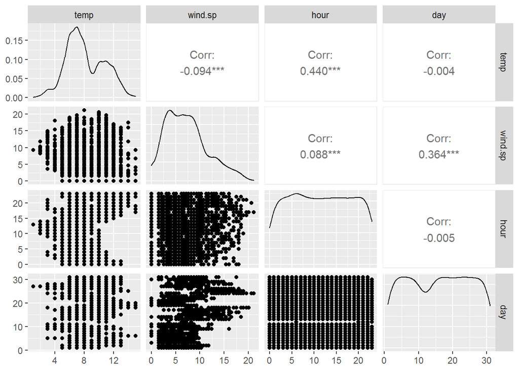

```r
highest %>%
  select(temp, wind.sp, hour, day) %>%
  GGally::ggpairs()
```

As we can see from the outputs above, there is a very small negative correlation between the recorded temperature and the day of the month at this weather station, but there is a moderately strong positive correlation between the temperature recorded and the hour at which the temperature was recorded.

On the other hand, the time of day and the day of the month are both positively correlated with the wind speed recorded at this weather station, but the strength of the correlation between the day of the month and the wind’s speed is much stronger than the correlation between the time of day and the wind’s speed.

### 7. Exploratory graphs

We should look at the distributions of all of the key variables (elevation, temp, wind speed) to make sure there are no remaining issues with the data.

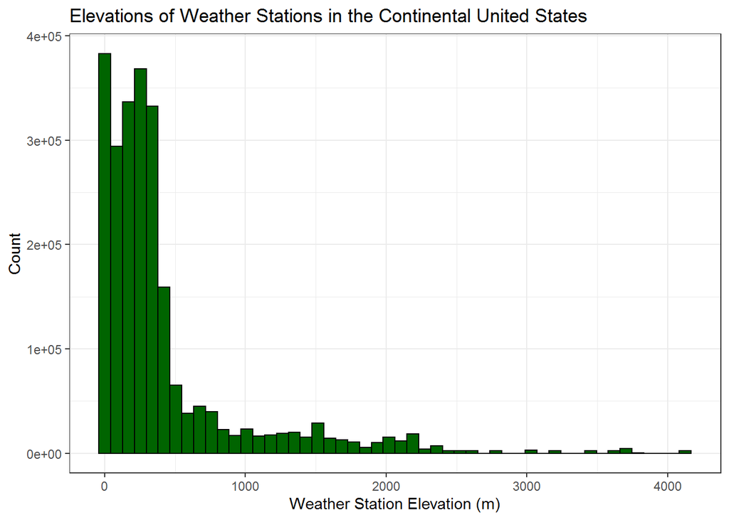

```r
ggplot(met, aes(x = elev)) +
  geom_histogram(color = "black", fill = "darkgreen", bins = 50) +
  labs(x = "Weather Station Elevation (m)", y = "Count",
       title = "Elevations of Weather Stations in the Continental United States") +
  theme_bw()
```

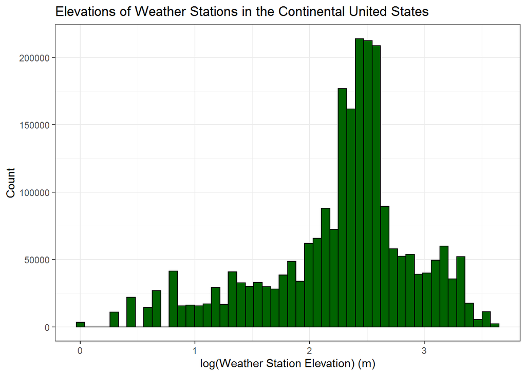

```r
ggplot(met, aes(x = log(elev, 10))) +
  geom_histogram(color = "black", fill = "darkgreen", bins = 50) +
  labs(x = "log(Weather Station Elevation) (m)", y = "Count",
       title = "Elevations of Weather Stations in the Continental United States") +
  theme_bw()
```

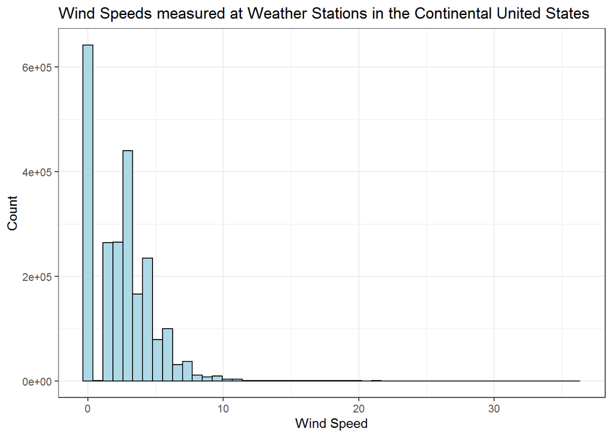

```r
ggplot(met, aes(x = wind.sp)) +
  geom_histogram(color = "black", fill = "lightblue", bins = 50) +
  labs(x = "Wind Speed", y = "Count",
       title = "Wind Speeds measured at Weather Stations in the Continental United States") +
  theme_bw()
```

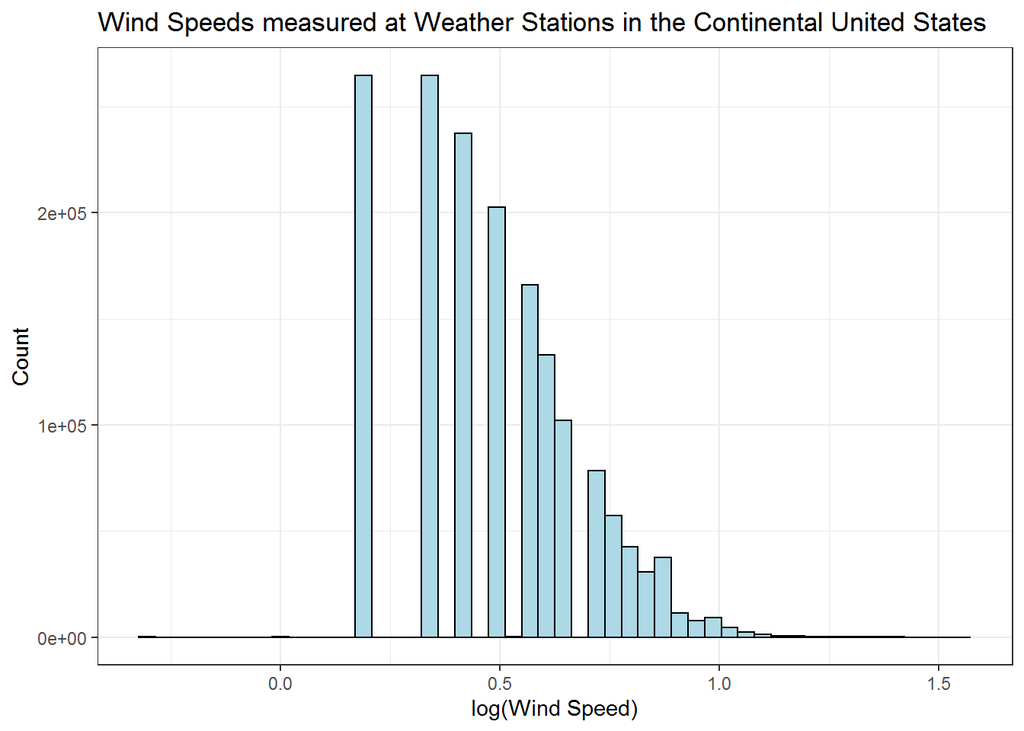

```r
ggplot(met, aes(x = log(wind.sp, 10))) +
  geom_histogram(color = "black", fill = "lightblue", bins = 50) +
  labs(x = "log(Wind Speed)", y = "Count",
       title = "Wind Speeds measured at Weather Stations in the Continental United States") +
  theme_bw()
```

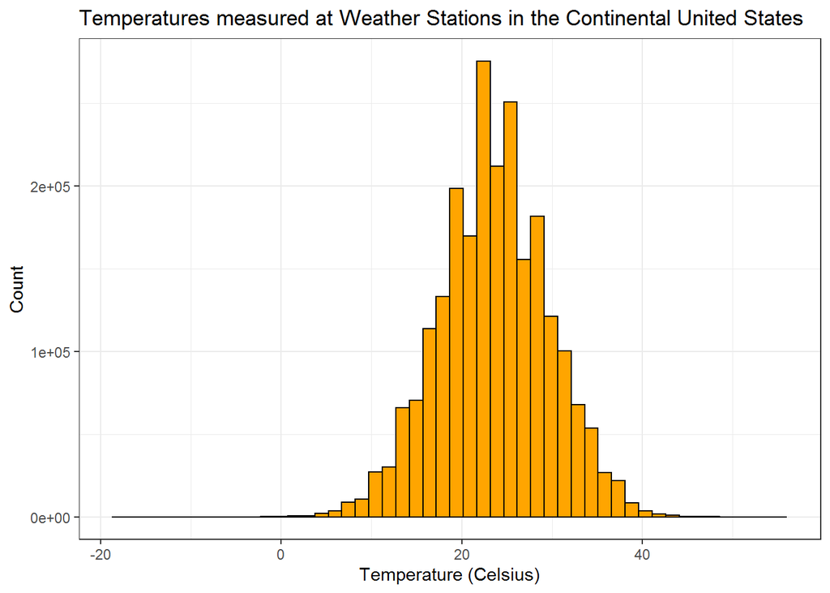

```r
ggplot(met, aes(x = temp)) +
  geom_histogram(color = "black", fill = "orange", bins = 50) +
  labs(x = "Temperature (Celsius)", y = "Count",
       title = "Temperatures measured at Weather Stations in the Continental United States") +
  theme_bw()
```

One thing we should consider for later analyses is to log transform wind speed and elevation as the are very skewed.

Look at where the weather station with highest elevation is located (i.e. make a map!)

```r
highest %>%
  leaflet() %>%
  addProviderTiles('OpenStreetMap') %>%
  addCircles(lat = ~lat, lng = ~lon, opacity = 1, fillOpacity = 1, radius = 100)
```

[interactive chart not shown]

As we can see from the open street map above, the weather station with the highest recorded elevation was in Colorado, due west of Denver. According to the map, the Colorado Mines Peak near this weather station is at an altitude of 3777 m, which reiterates how high this weather station is above sea level, as it is somewhere in the peaks of the Rocky Mountains.

- Summarize

Look at the time series of temperature and wind speed at this location. For this we will need to create a date-time variable for the x-axis.

```r
library(lubridate)
highest <- highest %>%
  mutate(date = ymd_h(paste(year, month, day, hour, sep = ' ')))

summary(highest$date)
```

```
##                  Min.               1st Qu.                Median
## "2019-08-01 00:00:00" "2019-08-08 10:15:00" "2019-08-16 21:00:00"
##                  Mean               3rd Qu.                  Max.
## "2019-08-16 13:15:37" "2019-08-24 09:00:00" "2019-08-31 22:00:00"
```

```r
head(highest %>% arrange(date))
```

```
##    USAFID WBAN year month day hour min  lat      lon elev wind.dir wind.dir.qc
## 1: 720385  419 2019     8   1    0  36 39.8 -105.766 4113      170           5
## 2: 720385  419 2019     8   1    0  54 39.8 -105.766 4113      100           5
## 3: 720385  419 2019     8   1    1  12 39.8 -105.766 4113       90           5
## 4: 720385  419 2019     8   1    1  35 39.8 -105.766 4113      110           5
## 5: 720385  419 2019     8   1    1  53 39.8 -105.766 4113      120           5
## 6: 720385  419 2019     8   1    2  12 39.8 -105.766 4113      120           5
##    wind.type.code wind.sp wind.sp.qc ceiling.ht ceiling.ht.qc ceiling.ht.method
## 1:              N     8.8          5       1372             5                 M
## 2:              N     2.6          5       1372             5                 M
## 3:              N     3.1          5       1981             5                 M
## 4:              N     4.1          5       2134             5                 M
## 5:              N     4.6          5       2134             5                 M
## 6:              N     6.2          5      22000             5                 9
##    sky.cond vis.dist vis.dist.qc vis.var vis.var.qc temp temp.qc dew.point
## 1:        N       NA           9       N          5    9       5         1
## 2:        N       NA           9       N          5    9       5         1
## 3:        N       NA           9       N          5    9       5         2
## 4:        N       NA           9       N          5    9       5         2
## 5:        N       NA           9       N          5    9       5         2
## 6:        N       NA           9       N          5    9       5         2
##    dew.point.qc atm.press atm.press.qc       rh                date
## 1:            5        NA            9 57.61039 2019-08-01 00:00:00
## 2:            5        NA            9 57.61039 2019-08-01 00:00:00
## 3:            5        NA            9 61.85243 2019-08-01 01:00:00
## 4:            5        NA            9 61.85243 2019-08-01 01:00:00
## 5:            5        NA            9 61.85243 2019-08-01 01:00:00
## 6:            5        NA            9 61.85243 2019-08-01 02:00:00
```

With the date-time variable we can plot the time series of temperature and wind speed.

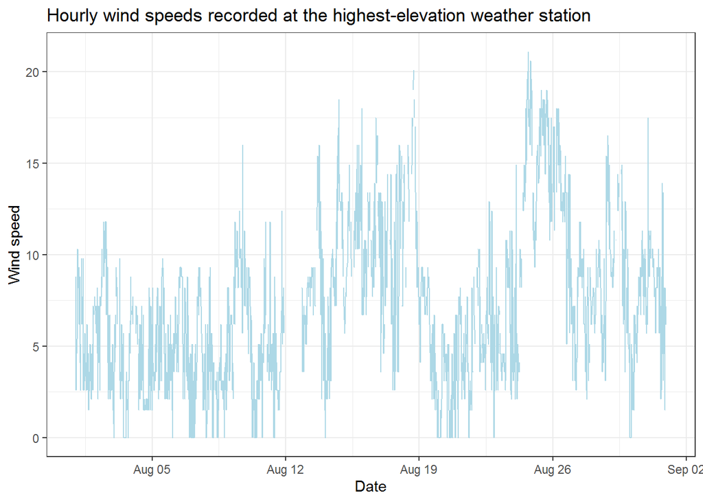

```r
ggplot(highest, aes(x = date, y = wind.sp)) +
  geom_line(color = "lightblue") +
  labs(x = "Date", y = "Wind speed",
       title = "Hourly wind speeds recorded at the highest-elevation weather station") +
  theme_bw()
```

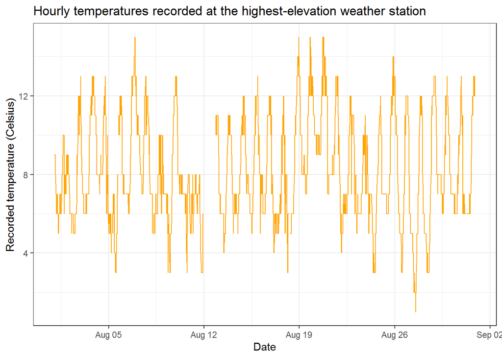

```r
ggplot(highest, aes(x = date, y = temp)) +
  geom_line(color = "orange") +
  labs(x = "Date", y = "Recorded temperature (Celsius)",
       title = "Hourly temperatures recorded at the highest-elevation weather station") +
  theme_bw()
```

Summarize any trends that you see in these time series plots.

In both of the time series plots depicted above, there are a few noticeable gaps in the data where the trendlines in the time series plots seem to disappear completely. The largest of these gaps occurs around August 12th, and the data ‘cuts out’ for a 12 to 24 hour period before returning.

The changes in the hourly wind speeds shown in the first time series plot are quite erratic. A possible explanation for these large and erratic changes in the wind speeds at this weather station is that the wind contains multiple components, such as its magnitude and direction (since it is a vector). Changes in the wind’s direction are not depicted in the time series plot above, but these changes may be useful in developing a ‘bigger picture’ with regard to the changes in the wind’s speed, and could possibly lead to a better explanation of the trends shown above.

On the other hand, the time series plot depicting the changes in temperature over time follows a significantly steadier pattern. Although there are rises and falls throughout the plot, the temperature increases and decreases in a steadier period of time, likely corresponding to the sun rising and setting throughout the day, as these periods appear to be about 24 hours in length. A steadier pattern such as this is very intuitive, since the most logical explanation for the temperatures nicely rising and falling (with some variation from day to day) would simply be the cycle of days and nights, and the light from the Sun, or the lack thereof.

# Deliverables

Submit your completed lab to Quercus as a html or pdf document. Fill in questions in steps 4,5,6,7.